# Flume Runs: 10/9/17 and 10/11/17

Justin Nghiem

10/18/17

*Source files* ⇒ LISST_AquaticPark.Rmd ⇒ C:_values.rds

### Flume run on 10/9/17

- sediment: Aquatic Park (collected 10/1/17)
- start collection: 11:45am
- end collection: 2:45pm
- start flume:
- frequency: 10 Hz
- flux: ~? to ? US gal/min
- water depth: 45 cm
- slope: 0.04%
- span:

The dataset has been processed to remove samples with optical transmission less than 0.1 or greater than 0.995. The plots of the densities use 10-minute time intervals (“groups”).

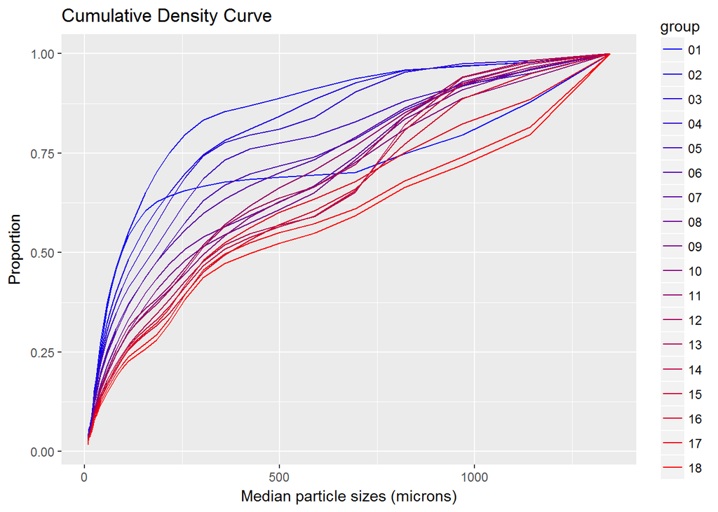

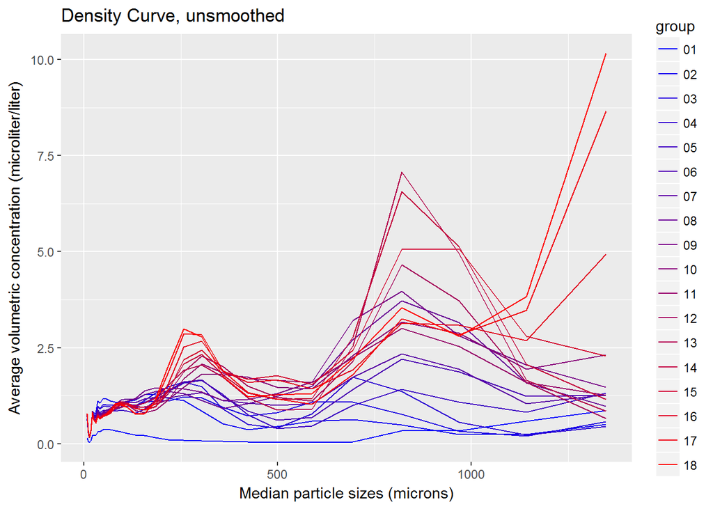

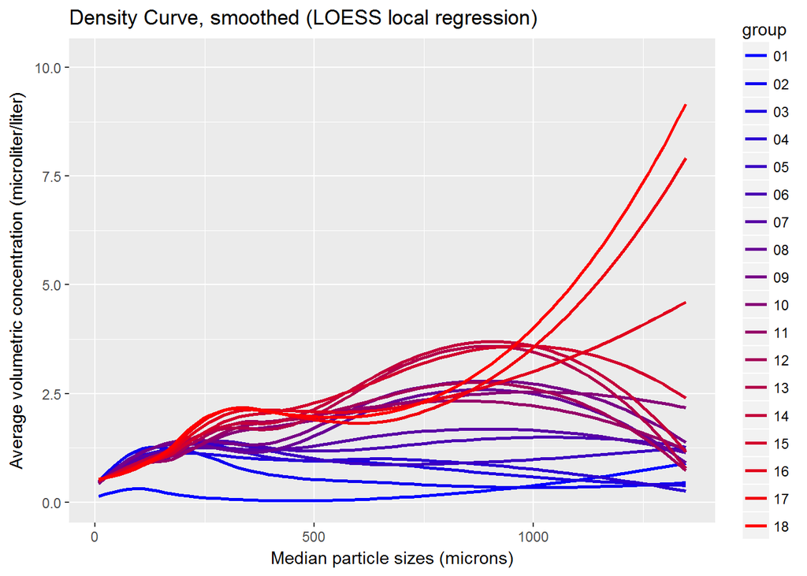

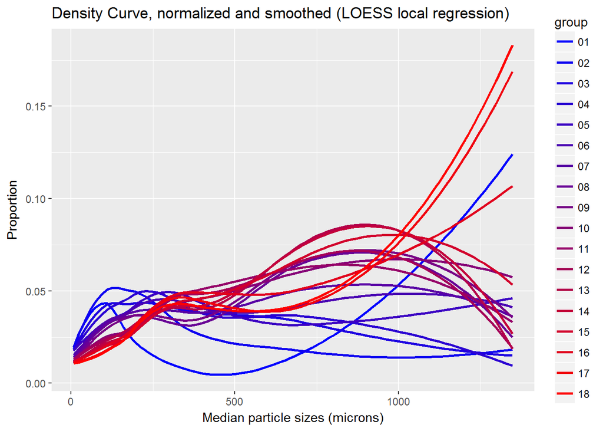

```
## [1] "Number of samples is 10095"
```

| group | avg_size |
| --- | --- |
| 1 | 1116.4847 |
| 2 | 1026.2066 |
| 3 | 948.4538 |
| 9 | 985.6453 |
| 10 | 195.8343 |
| 11 | 111.5602 |
| 12 | 123.5679 |
| 13 | 225.1651 |
| 14 | 287.9551 |
| 15 | 271.1503 |
| 16 | 287.3757 |
| 17 | 265.9433 |
| 18 | 294.6116 |
| 19 | 303.5348 |
| 20 | 247.7248 |
| 21 | 182.4168 |
| 22 | 192.8063 |
| 23 | 214.7049 |
| 24 | 279.0410 |
| 25 | 313.6907 |
| 26 | 295.3474 |
| 27 | 289.7930 |
| 28 | 306.9059 |
| 29 | 254.5730 |
| 30 | 255.2428 |
| 31 | 270.3995 |
| 32 | 254.3076 |
| 33 | 242.4869 |
| 34 | 256.4920 |
| 35 | 261.8727 |

[output cut: 143 more lines]

`group` denotes the time interval. For example, `group` 1 is the time from the start of the experiment with a length of the time interval. `avg_size` is the mean particle size in microns. In the table above, time intervals are 1-minute. The plot of the table is:

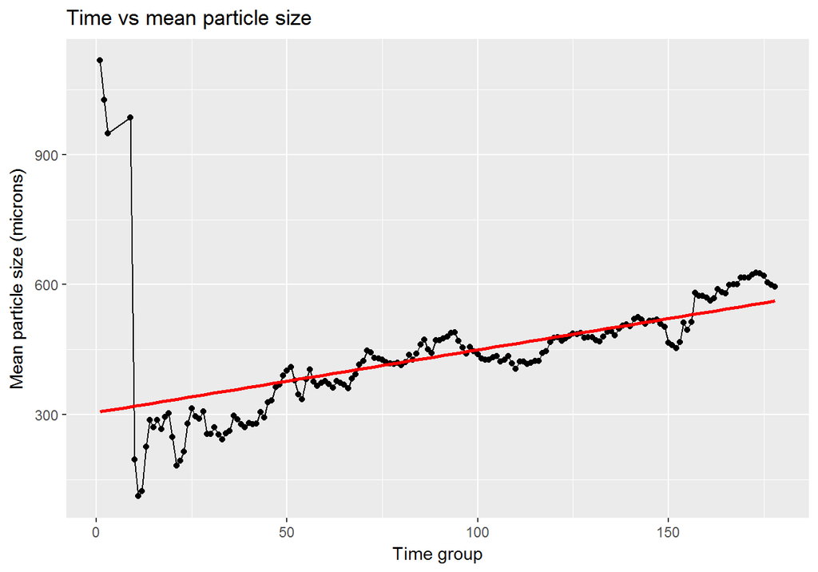

The `mean` of mean particle sizes is 437.7713763. The `standard deviation` of mean particle sizes is 140.3906402. The $R^2$ value is 0.2669227

### Flume run on 10/11/17

- sediment: same as previous run
- start collection: 10:30am
- end collection: 1:30pm
- start flume: 10:35am
- frequency: 30 Hz
- flux: ~214 to 216 US gal/min
- water depth: 45 cm
- slope: 0.04%
- span: ~31%

#### Notes

- sediment had settled to flume bed after run on 10/9
- cavitation at 40 and 35 Hz
- flow stabilized at 30 Hz at 10:39:09am
- opening to sensor aligned parallel to flow
- some sediment trapped under the false bed in the test section

The dataset has *not* been processed to remove samples with optical transmission less than 0.1 or greater than 0.995 because only 9 data points will remain after such processing. The plots of the densities use 10-minute time intervals (“groups”).

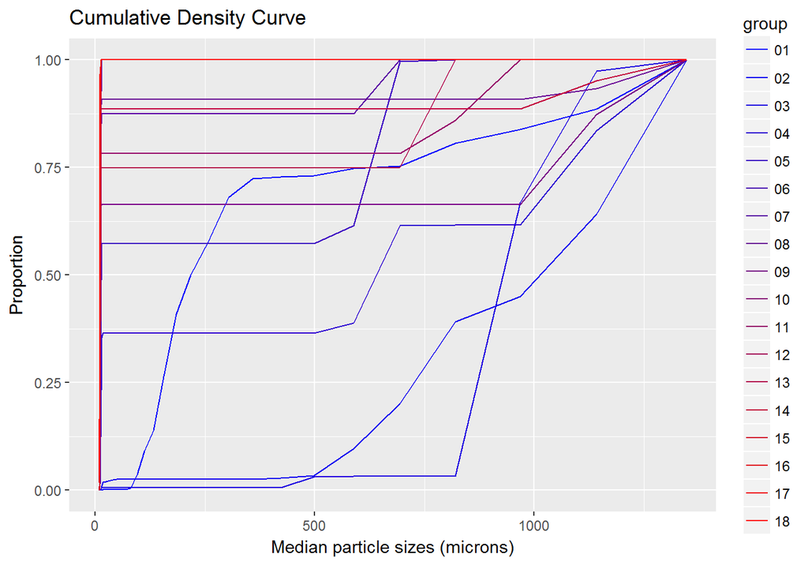

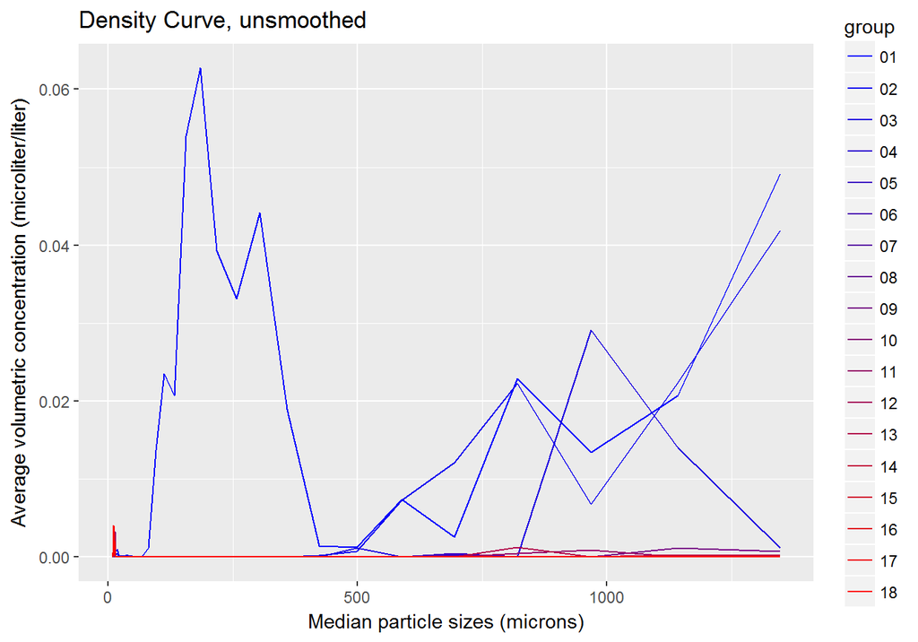

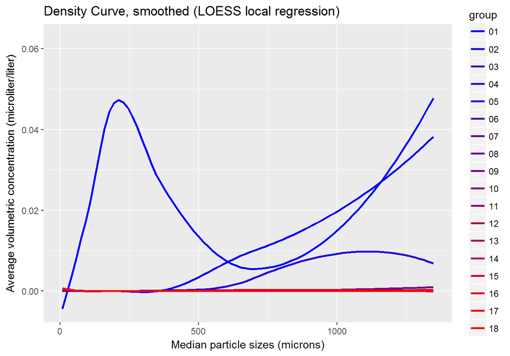

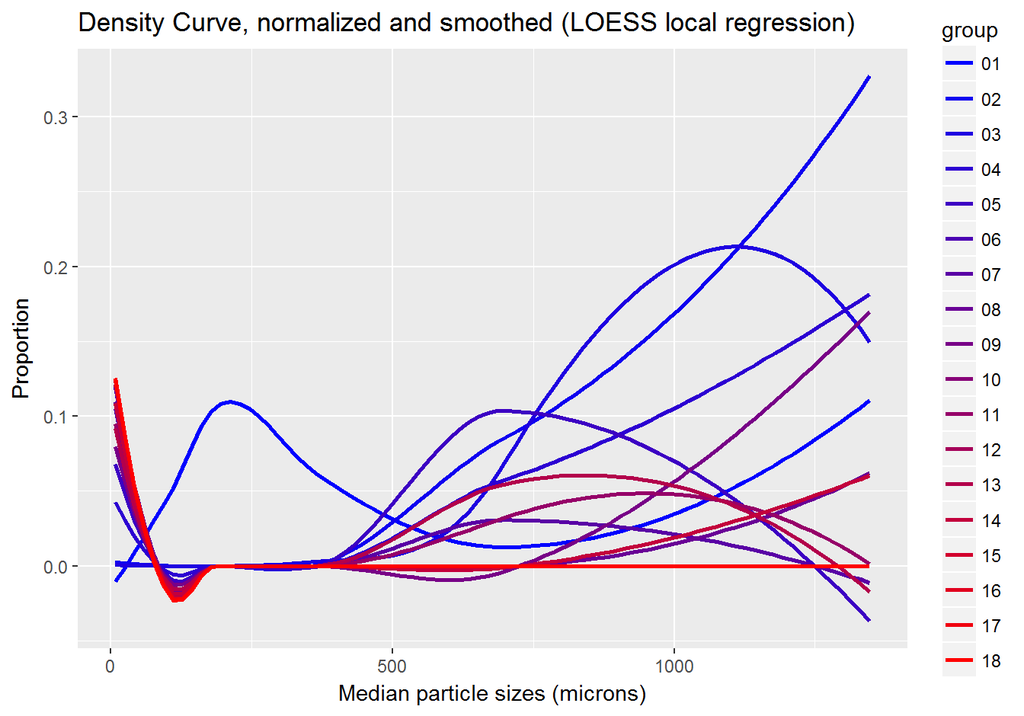

```
## [1] "Number of samples is 10802"
```

| group | avg_size |
| --- | --- |
| 1 | 0.00000 |
| 2 | 0.00000 |
| 3 | 0.00000 |
| 4 | 0.00000 |
| 5 | 0.00000 |
| 6 | 0.00000 |
| 7 | 480.59445 |
| 8 | 280.29814 |
| 9 | 932.76757 |
| 10 | 1229.93322 |
| 11 | 1109.15045 |
| 12 | 1007.63522 |
| 13 | 0.00000 |
| 14 | 1023.18689 |
| 15 | 15.87093 |
| 16 | 0.00000 |
| 17 | 0.00000 |
| 18 | 16.38879 |
| 19 | 1119.97012 |
| 20 | 0.00000 |
| 21 | 15.97112 |
| 22 | 15.42000 |
| 23 | 0.00000 |
| 24 | 1074.75900 |
| 25 | 14.30110 |
| 26 | 0.00000 |
| 27 | 14.27353 |
| 28 | 894.81912 |
| 29 | 13.84154 |
| 30 | 987.40429 |

[output cut: 150 more lines]

In the table above, time intervals are 1-minute. The plot of the table is:

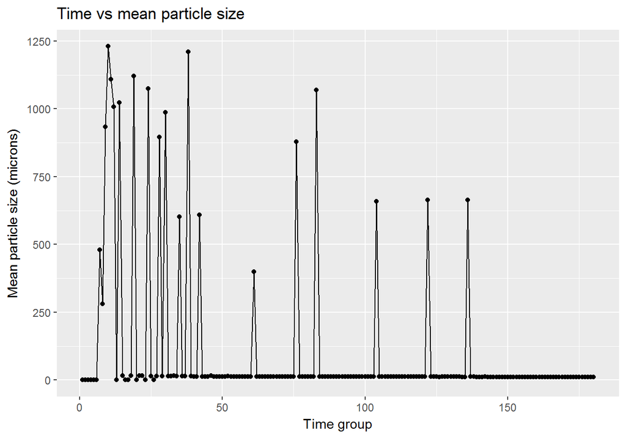

The `mean` of mean particle sizes is 104.0094935. The `standard deviation` of mean particle sizes is 277.965333.